# Hypothesis Testing

1.1 Hypothesis testing - practical

```r
library(tidyverse)
library(infer)
data(msleep)
```

2. Is the mean(sleep_total) the same as the jaberwockies sleep total (7 hours)?

alpha; 0.05 HO; mean(sleep_total) - 7 = 0 HA; mean(sleep_total) - 7 != 0

Calculate test statistic

```r
mean_diff_sleep <- mean(msleep$sleep_total) - 7
```

Mean is much higher than 7. HA is likely true

```r
null_distribution <- msleep %>%
  specify(response = sleep_total) %>%    # response = what we care about (average rating)
  hypothesise(null = "point", mu = mean_diff_sleep) %>%  # this time we also hypothesise
  generate(reps = 2000, type = "bootstrap") %>%   # type will change for different tests
  calculate(stat = "mean")
```

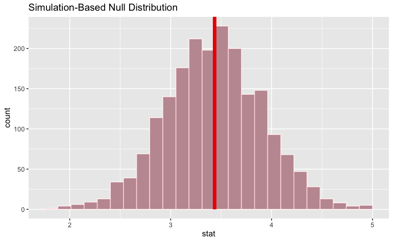

```r
null_distribution %>%
  visualise(bins = 25) +
  shade_p_value(obs_stat = mean_diff_sleep,
                direction = "both")
```

```r
null_distribution %>%
  get_p_value(
    obs_stat = mean(msleep$sleep_total),
    direction = "both")
```

| p_value |
| --- |
| 0 |

p is <0.001! Meaning we can reject the null hypothesis

3. Perform an appropriate statistical test to determine whether omnivores sleep for significantly longer than herbivores, on average.

Average means we’re working with mean.

Basically, group by diet type then mean(sleep_total)

Start with herbivores

```r
avg_herbi <- msleep %>%
  filter(vore == "herbi") %>%
  group_by(vore) %>%
  summarise(mean = mean(sleep_total))

avg_omni <- msleep %>%
  filter(vore == "omni") %>%
  group_by(vore) %>%
  summarise(mean = mean(sleep_total))
```

avg_herbi = 9.5

HO: avg_omni - 9.5 = 0 HA: avg_omni - 9.5 > 0

```r
mean_diff <- avg_omni$mean - avg_herbi$mean

null_distribution_q3 <- msleep %>%
  specify(response = sleep_total) %>%    # response = what we care about (average rating)
  hypothesise(null = "point", mu = mean_diff) %>%  # this time we also hypothesise
  generate(reps = 10000, type = "bootstrap") %>%   # type will change for different tests
  calculate(stat = "mean")
```

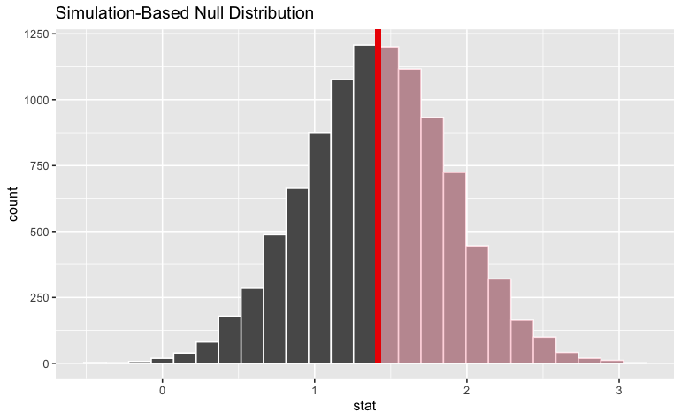

```r
null_distribution_q3 %>%
  visualise(bins = 25) +
  shade_p_value(obs_stat = mean_diff,
                direction = "greater") # direction depends on your hypothosese
```

```r
null_distribution_q3 %>%
  get_p_value(
    obs_stat = mean_diff,
    direction = "less")
```

| p_value |
| --- |
| 0.5037 |

p > alpha, therefore we can NOT reject the null hypothesis.

4. Perform an appropriate statistical test to determine whether the proportion of domesticated animal types in the population of animal types is greater than 5%

one sample prop, therefore:

```r
# one sample prop
# data %>%
#   specify(response = "col of interest", success = "success condition") %>%
#   hypothesise(null = "point", p = x) %>%
#   generate(reps = yyyy, type = "draw") %>%
#   calculate(stat = "prop")
```

H0: prop_domesticated animals = 0.05 HA: prop_domesticated animals > 0.05

```r
msleep <- msleep %>%
  mutate(is_domesticated = conservation == "domesticated")
```

Calculate test statistic

```r
prop_domesticated <- msleep %>%
  filter(is_domesticated == TRUE) %>%
  summarise(prop = n() / nrow(msleep))
```

```r
null_distribution_q4
```

```
Response: is_domesticated (factor)
Null Hypothesis: point
```

| replicate | stat |
| --- | --- |
| 1 | 0.10 |
| 2 | 0.05 |
| 3 | 0.15 |
| 4 | 0.10 |
| 5 | 0.00 |
| 6 | 0.00 |
| 7 | 0.00 |
| 8 | 0.15 |
| 9 | 0.15 |
| 10 | 0.05 |

[output cut: 990 more lines]

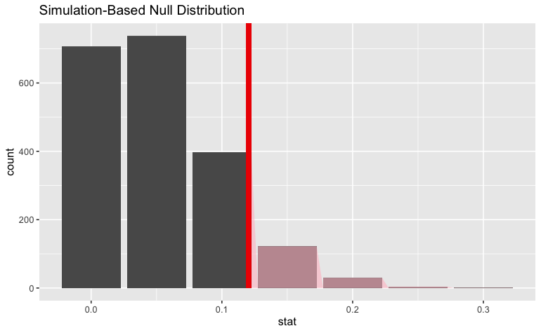

```r
null_distribution_q4 %>%
  visualise(bins = 25) +
  shade_p_value(obs_stat = prop_domesticated,
                direction = "greater") # direction depends on your hypothosese
```

```r
null_distribution_q4 %>%
  get_p_value(
    obs_stat = prop_domesticated,
    direction = "greater")
```

| p_value |
| --- |
| 0.0785 |

p > 0.05, therefore we may not reject the null hypothesis in favour of HA.

1.2 Hypothesis testing - Defining the Hypothesis

For the following three business problems write out:

What kind of test you would use H0 and Ha in both mathematical notation and in words. Also state the method you would use to generate the null distribution (bootstrap, permutation or draw).

1. Boss thinks that 40% of the town knows about the coffee shop. I think it is higher than 40%

I have one sample of 200 and I am working with proportions, I would perform a draw (one sample proportion) test.

H0: people_knowing_about_coffee_shop = 0.4 HA; people_knowing_about_coffee_shop > 0.4

2. “that website users overall are more likely to click on the banner if positioned at the top of the page”

Group A continued to be shown the banner at the right hand side of the webpage (its usual position)

group B was shown the banner at the top of the page

proportion

Will the CTR (click through rate) be higher for group B?

H0: CTR_group_A - CTR_group_B >= 0 HA: CTR_group_A - CTR_group_B < 0

H0: Those in group A (banner at right of page), are more likely to click (have a higher CTR) than those of group B (banner at TOP of page)

HA: Those in group A(banner at right of page), are less likely to click (have a higher CTR) than those of group B (banner at TOP of page)

I would use two-sample independent testing, with permutations.

3. H0: mean_part_width - 145 = 0 HA: mean_part_width - 145 != 0

H0: the mean_part_width is 145mm HA: the mean_part_width is not 145mm

We have one sample only. We are dealing with means rather than proportions. Therefore we will use bootstrapping

1.3 Hypothesis Testing - Interpreting the results 1. H0: people_knowing_about_coffee_shop = 0.4 HA; people_knowing_about_coffee_shop > 0.4

Coffee shop problem. Significance level: 0.05, calculated p -value: 0.07

If p > alpha, we can’t reject the null hypothesis. 0.07 > 0.05

We can’t reject the null hypothesis.

2. H0: CTR_group_A - CTR_group_B >= 0 HA: CTR_group_A - CTR_group_B < 0

Website company problem. Significance level: 0.01, p -value: 0.006

3. H0: mean_part_width - 145 = 0 HA: mean_part_width - 145 != 0

Manufacturing company problem. Significance level: 0.05, p -value: 0.55

If p > alpha, we can’t reject the null hypothesis.